# 5.2 scikit-learn（2）：分类分析

```python
import pandas as pd
import numpy as np
import matplotlib.pyplot as plt
plt.rcParams['font.sans-serif']=['SimHei']
plt.rcParams['axes.unicode_minus']=False
```

# Table of Contents

## 上周作业

```python
from sklearn import linear_model as lm
```

```python
data=pd.read_excel('上周作业数据/青春有你3.xlsx')
data.head()
```

|  | 选手姓名 | 国家/地区 | 身高 | 体重 | 经纪公司 | Height | Weight |
| --- | --- | --- | --- | --- | --- | --- | --- |
| 0 | 爱尔法·金 | 中国新疆 | 184cm | 65kg | 快享星合 | 184.0 | 65.0 |
| 1 | 艾克里里 | 中国广东 | 174cm | 55kg | 领优经纪 | 174.0 | 55.0 |
| 2 | 艾力扎提 | 中国新疆 | 178cm | 56kg | 简单快乐 | 178.0 | 56.0 |
| 3 | 阿煜 | 中国广东 | 176cm | 57kg | 瑾和娱乐 | 176.0 | 57.0 |
| 4 | 白丁 | 中国四川 | 177cm | 65kg | 少城时代 | 177.0 | 65.0 |

```python
data['身高']
```

```
0      184cm
1      174cm
2      178cm
3      176cm
4      177cm
       ...
114    181cm
115    180cm
116    176cm
117    180cm
118    180cm
Name: 身高, Length: 119, dtype: object
```

```python
data['身高'][0]
```

```
'184cm'
```

```python
data['身高'][0][0]
```

```
'1'
```

```python
data['身高'][0][:-2]
```

```
'184'
```

```python
float(data['身高'][0][:-2])
```

```
184.0
```

```python
H=[]
for i in data['身高']:
    H.append(float(i[:-2]))
```

```python
print(H)
```

```
[184.0, 174.0, 178.0, 176.0, 177.0, 186.0, 183.0, 180.0, 175.0, 184.0, 175.0, 178.0, 179.0, 181.0, 177.0, 186.0, 169.0, 183.0, 187.0, 182.0, 183.0, 180.0, 183.0, 176.0, 183.0, 180.0, 185.0, 178.0, 183.0, 177.0, 183.0, 184.0, 182.0, 186.0, 175.0, 181.0, 175.0, 178.0, 183.0, 176.0, 180.0, 175.0, 180.0…
```

```python
W=[]
for i in data['体重']:
    W.append(float(i[:-2]))
print(W)
```

```
[65.0, 55.0, 56.0, 57.0, 65.0, 68.0, 60.0, 110.0, 53.8, 70.0, 52.0, 65.0, 56.0, 63.0, 57.0, 72.0, 89.0, 60.0, 68.0, 63.0, 71.0, 58.0, 65.0, 60.0, 65.0, 56.0, 68.0, 56.8, 55.0, 62.5, 62.0, 67.0, 60.0, 75.0, 55.0, 59.0, 59.0, 60.0, 65.5, 62.0, 60.0, 91.0, 65.0, 65.0, 50.0, 65.0, 63.0, 60.0, 58.0, 55.0…
```

```python
homework = lm.LinearRegression().fit(H,W)
```

[output not shown]

```python
homework = lm.LinearRegression().fit(np.array(H).reshape(-1, 1),np.array(W).reshape(-1, 1))
```

```python
print('拟合结果：体重=%f×身高%f'%(homework.coef_,homework.intercept_))
```

```
拟合结果：体重=0.572283×身高-40.102732
```

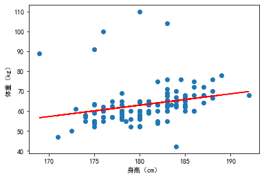

```python
fig,ax=plt.subplots()
ax.scatter(H,W)
ax.plot(H,homework.predict(np.array(H).reshape(-1, 1)),c='red')
ax.set_xlabel('身高（cm）')
ax.set_ylabel('体重（kg）')
```

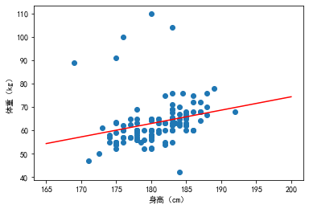

```python
xxx=[165,200]
fig,ax=plt.subplots()
ax.scatter(H,W)
ax.plot(xxx,homework.predict(np.array(xxx).reshape(-1, 1)),c='red')
ax.set_xlabel('身高（cm）')
ax.set_ylabel('体重（kg）')
```

## 什么是分类分析（classification analysis）

在机器学习和统计中，分类是基于包含其类别成员资格已知的观察（或实例）的训练数据集来识别新观察所属的一组类别（子群体）中的哪一个的问题。例如，将给定的电子邮件分配给“垃圾邮件”或“非垃圾邮件”类，并根据观察到的患者特征（性别，血压，某些症状的存在或不存在等）为给定患者分配诊断。

分类是一个有监督的学习过程，目标数据库中**有哪些类别是已知**的，分类过程需要做的就是把每一条记录归到对应的类别之中。由于必须事先知道各个类别的信息，并且所有待分类的数据条目都默认有对应的类别，因此分类算法也有其局限性，当上述条件无法满足时，我们就需要尝试聚类分析。

通常，将各个观察结果分析为一组可量化的属性，不同地称为解释变量或特征。这些属性可以不同地分类（例如，“A”，“B”，“AB”或“O”，对于血型），序数（例如“大”，“中”或“小”），整数值（例如，电子邮件中特定单词的出现次数）或实际值（例如血压的测量值）。

实现分类的算法，特别是在具体实现中，被称为分类器。术语“分类器”有时也指由分类算法实现的数学函数，其将输入数据映射到类别。

## 基于支持向量机（SVM）的分类模型

使用SVM分类，实质是构建与能够使离超平面最近的数据点的到超平面距离最大的超平面。

[figure not shown]

参考：https://zhuanlan.zhihu.com/p/49331510

## sklearn的线性SVM分类模型实现

### 例1.随机数据的演示

```python
from sklearn.svm import SVC #从sklearn的SVM模型中导入SVC方法
```

注意：SVC的拟合所需时间是$O(n^2)$的，即时间正比于样本量的平方。如果样本量过大，该方法可行性就很差，可以使用sklearn.svm.LinearSVC 或者 sklearn.linear_model.SGDClassifier 替代

参考https://scikit-learn.org/stable/modules/generated/sklearn.svm.SVC.html#sklearn.svm.SVC

```python
X0=np.random.rand(100,2)
Y0=np.array([0]*100)
```

上边，随机生成一组样本量为100的[0,1]之间的随机二维坐标，并将其分类记为0

```python
X1=np.random.rand(100,2)+0.8
Y1=np.array([1]*100)
```

下边，我们把这两组数据画在图上

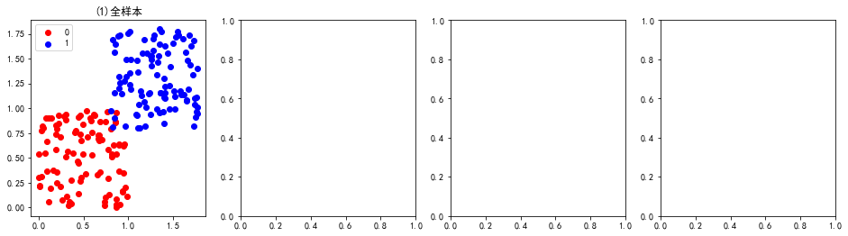

```python
fig,ax=plt.subplots(1,4,figsize=(16,4))
ax[0].scatter(X0[:,0],X0[:,1],c='red',label='0')
ax[0].scatter(X1[:,0],X1[:,1],c='blue',label='1')
ax[0].legend()
ax[0].set_title('(1)全样本')
```

下边，我们在这两组样本中各取一半，组成用于机器学习的样本，另一半用于检验。

```python
X_study=np.vstack((X0[0:50],X1[0:50]))
Y_study=np.hstack((Y0[0:50],Y1[0:50]))
X_test=np.vstack((X0[50:],X1[50:]))
Y_test=np.hstack((Y0[50:],Y1[50:]))
```

下边，画出用于学习的样本和用于检验的样本

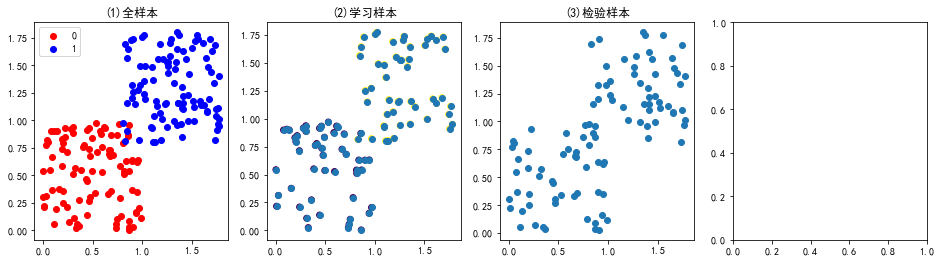

```python
ax[1].scatter(X_study[:,0],X_study[:,1])
ax[1].set_title('(2)学习样本')

ax[2].cla()
ax[2].scatter(X_test[:,0],X_test[:,1])
ax[2].set_title('(3)检验样本')
fig
```

**构建线性SVM分类模型**

```python
clf = SVC(kernel='linear')  #构建SVC对象，kernel='linear'意为线性模型
clf.fit(X_study, Y_study)  #使用fit方法进行拟合
```

```
SVC(kernel='linear')
```

```python
Y_predict=clf.predict(X_test) #用构建的模型对检验样本做分类
```

将检验结果画到图上

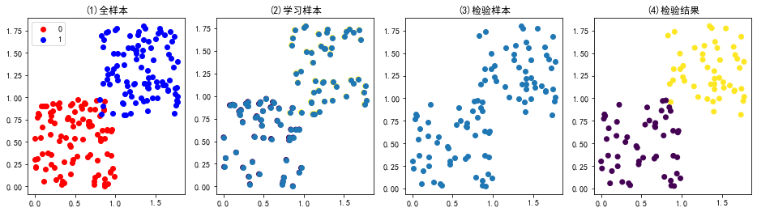

```python
ax[3].cla()
ax[3].scatter(X_test[:,0],X_test[:,1],c=Y_predict)
ax[3].set_title('(4)检验结果')
fig
```

同样可以使用score方法对模型进行评价

```python
clf.score(X_test,Y_test)
```

```
0.97
```

### 例 2. 通过身高体重判断男女

```python
boy1=pd.read_csv('青春有你1.csv',index_col=0)
girl=pd.read_csv('青春有你2.csv',index_col=0)
boy2=pd.read_excel('青春有你3.xlsx',index_col=0)
```

```python
boy2.head()
```

| 选手姓名 | 身高 | 体重 |
| --- | --- | --- |
| 爱尔法·金 | 184.0 | 65.0 |
| 艾克里里 | 174.0 | 55.0 |
| 艾力扎提 | 178.0 | 56.0 |
| 阿煜 | 176.0 | 57.0 |
| 白丁 | 177.0 | 65.0 |

```python
test=pd.read_csv('待测.csv',index_col=0,encoding='gbk')
test.head()
```

|  | 性别 | 身高 | 体重 |
| --- | --- | --- | --- |
| 周杰伦 | 1 | 175 | 70 |
| 刘诗诗 | 0 | 165 | 48 |
| 赵丽颖 | 0 | 165 | 45 |
| 张一山 | 1 | 176 | 55 |
| 郑恺 | 1 | 178 | 73 |

将《青春有你》三季选手数据作为学习数据

```python
X_boy1=boy1.values
X_girl=girl.values
X_boy2=boy2.values
Y_boy1=np.array([1]*len(boy1))
Y_girl=np.array([0]*len(girl))
Y_boy2=np.array([1]*len(boy2))
```

```python
X_boy1
```

```
array([[181. ,  50. ],
       [178. ,  60. ],
       [175. ,  55. ],
       [182. ,  62. ],
       [187. ,  65. ],
       [180. ,  64. ],
       [183. ,  65. ],
       [180. ,  58. ],
       [187. ,  70. ],
       [180. ,  63. ],
       [185. ,  68. ],
       [178. ,  63. ],
       [184. ,  63. ],
       [176. ,  63. ],
       [178. ,  59. ],
       [184. ,  63. ],
       [178. ,  60. ],
       [183. ,  65. ],
       [185. ,  70. ],
       [175. ,  62. ],
       [180. ,  62. ],
       [188. ,  70. ],
       [183. ,  58. ],
       [188. ,  70. ],
       [186. ,  68. ],
       [175. ,  59. ],
       [181. ,  61. ],
       [184. ,  65. ],
       [183. ,  69. ],
       [183. ,  60. ],
       [189. ,  75. ],
       [182. ,  65. ],
       [178. ,  53.5],
       [183. ,  63. ],
       [180. ,  62. ],
       [179. ,  57. ],
       [178. ,  62. ],
       [186. ,  75. ],
       [174. ,  62. ],
       [180. ,  62. ],
```

[output cut: 45 more lines]

```
       [181. ,  65. ],
       [180. ,  60. ],
       [180. ,  62. ],
       [181. ,  65. ],
       [176. ,  60. ],
       [176. ,  50. ],
       [184. ,  68. ],
       [175. ,  50. ],
       [186. ,  60. ],
       [175. ,  50. ],
       [183. ,  66. ],
       [178. ,  68. ],
       [180. ,  66. ],
       [184. ,  60. ],
       [180. ,  63. ]])
```

```python
X_idol_study=np.vstack((X_boy1,X_girl,X_boy2))
```

```python
X_idol_study
```

```
array([[181. ,  50. ],
       [178. ,  60. ],
       [175. ,  55. ],
       [182. ,  62. ],
       [187. ,  65. ],
       [180. ,  64. ],
       [183. ,  65. ],
       [180. ,  58. ],
       [187. ,  70. ],
       [180. ,  63. ],
       [185. ,  68. ],
       [178. ,  63. ],
       [184. ,  63. ],
       [176. ,  63. ],
       [178. ,  59. ],
       [184. ,  63. ],
       [178. ,  60. ],
       [183. ,  65. ],
       [185. ,  70. ],
       [175. ,  62. ],
       [180. ,  62. ],
       [188. ,  70. ],
       [183. ,  58. ],
       [188. ,  70. ],
       [186. ,  68. ],
       [175. ,  59. ],
       [181. ,  61. ],
       [184. ,  65. ],
       [183. ,  69. ],
       [183. ,  60. ],
       [189. ,  75. ],
       [182. ,  65. ],
       [178. ,  53.5],
       [183. ,  63. ],
       [180. ,  62. ],
       [179. ,  57. ],
       [178. ,  62. ],
       [186. ,  75. ],
       [174. ,  62. ],
       [180. ,  62. ],
```

[output cut: 273 more lines]

```
       [175. ,  63.5],
       [180. ,  60. ],
       [188. ,  70. ],
       [178. ,  58. ],
       [181. ,  60. ],
       [187. ,  72. ],
       [178. ,  69. ],
       [183. ,  69. ],
       [175. ,  55. ],
       [179. ,  60. ],
       [181. ,  65. ],
       [180. ,  52. ],
       [176. ,  60. ],
       [180. ,  60. ],
       [180. ,  58. ]])
```

```python
Y_idol_study=np.hstack((Y_boy1,Y_girl,Y_boy2))
```

```python
Y_idol_study
```

```
array([1, 1, 1, 1, 1, 1, 1, 1, 1, 1, 1, 1, 1, 1, 1, 1, 1, 1, 1, 1, 1, 1,
       1, 1, 1, 1, 1, 1, 1, 1, 1, 1, 1, 1, 1, 1, 1, 1, 1, 1, 1, 1, 1, 1,
       1, 1, 1, 1, 1, 1, 1, 1, 1, 1, 1, 1, 1, 1, 1, 1, 1, 1, 1, 1, 1, 1,
       1, 1, 1, 1, 1, 1, 1, 1, 1, 1, 1, 1, 1, 1, 1, 1, 1, 1, 1, 1, 1, 1,
       1, 1, 1, 1, 1, 1, 1, 1, 1, 1, 1, 1, 0, 0, 0, 0, 0, 0, 0, 0, 0, 0,
       0, 0, 0, 0, 0, 0, 0, 0, 0, 0, 0, 0, 0, 0, 0, 0, 0, 0, 0, 0, 0, 0,
       0, 0, 0, 0, 0, 0, 0, 0, 0, 0, 0, 0, 0, 0, 0, 0, 0, 0, 0, 0, 0, 0,
       0, 0, 0, 0, 0, 0, 0, 0, 0, 0, 0, 0, 0, 0, 0, 0, 0, 0, 0, 0, 0, 0,
       0, 0, 0, 0, 0, 0, 0, 0, 0, 0, 0, 0, 0, 0, 0, 0, 0, 0, 0, 0, 0, 0,
       0, 0, 0, 0, 0, 0, 0, 0, 0, 0, 0, 1, 1, 1, 1, 1, 1, 1, 1, 1, 1, 1,
       1, 1, 1, 1, 1, 1, 1, 1, 1, 1, 1, 1, 1, 1, 1, 1, 1, 1, 1, 1, 1, 1,
       1, 1, 1, 1, 1, 1, 1, 1, 1, 1, 1, 1, 1, 1, 1, 1, 1, 1, 1, 1, 1, 1,
       1, 1, 1, 1, 1, 1, 1, 1, 1, 1, 1, 1, 1, 1, 1, 1, 1, 1, 1, 1, 1, 1,
       1, 1, 1, 1, 1, 1, 1, 1, 1, 1, 1, 1, 1, 1, 1, 1, 1, 1, 1, 1, 1, 1,
       1, 1, 1, 1, 1, 1, 1, 1, 1, 1, 1, 1, 1, 1, 1, 1, 1, 1, 1, 1])
```

```python
X_test=test.values[:,1:] #待检测明星数据
Y_test=test.values[:,0]
```

```python
X_test=test[['身高','体重']].values
```

```python
Y_test=test[['性别']].values
```

```python
Y_test
```

```
array([[1],
       [0],
       [0],
       [1],
       [1],
       [0],
       [1],
       [1],
       [1],
       [1],
       [1],
       [0],
       [1],
       [1],
       [1],
       [0],
       [0],
       [0],
       [0],
       [1]], dtype=int64)
```

画出学习样本、测样本的分布图

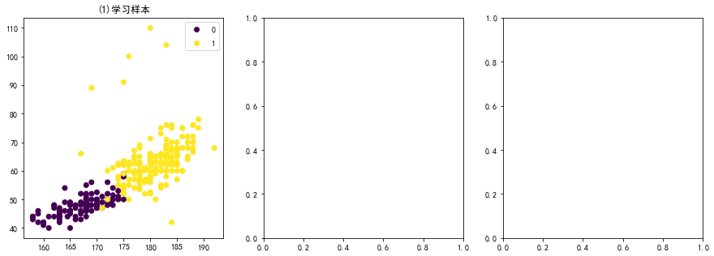

```python
fig1,ax1=plt.subplots(1,3,figsize=(15,5))
studypic=ax1[0].scatter(X_idol_study[:,0],X_idol_study[:,1],c=Y_idol_study)
handles, labels = studypic.legend_elements(prop="colors")
ax1[0].legend(handles,labels)
ax1[0].set_title('(1)学习样本')
```

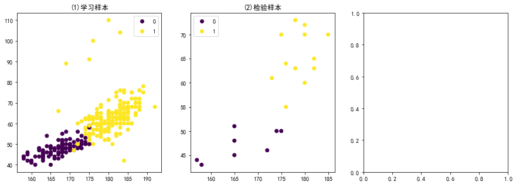

```python
testpic=ax1[1].scatter(X_test[:,0],X_test[:,1],c=Y_test)
handles, labels = testpic.legend_elements(prop="colors")
ax1[1].legend(handles,labels)
ax1[1].set_title('(2)检验样本')
fig1
```

构建线性SVM模型，应用fit方法进行拟合，得到拟合模型后对待检验样本使用predict方法进行检验

```python
clf_idol = SVC(kernel='linear')  #构建SVC对象，kernel='linear'意为线性模型
clf_idol.fit(X_idol_study, Y_idol_study)  #使用fit方法进行拟合
```

```
SVC(kernel='linear')
```

```python
Y_idol_predict=clf_idol.predict(X_test) #用构建的模型对检验样本做分类
```

将检验结果画到图中

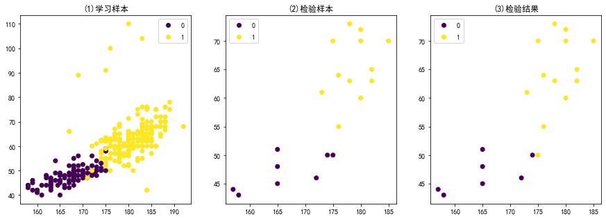

```python
exampic=ax1[2].scatter(X_test[:,0],X_test[:,1],c=Y_idol_predict)
handles, labels = exampic.legend_elements(prop="colors")
ax1[2].legend(handles,labels)
ax1[2].set_title('(3)检验结果')
fig1
```

应用score方法检验模型效果

```python
clf_idol.score(X_idol_study, Y_idol_study)
```

```
0.9725609756097561
```

```python
clf_idol.score(X_test,Y_test)
```

```
0.95
```

## 支持向量机的多元分类

SVC 和 NuSVC 为多元分类实现了 “one-against-one” 的方法 (Knerr et al., 1990) 如果 n_class 是类别的数量, 那么 n_class * (n_class - 1) / 2 分类器被重构, 而且每一个从两个类别中训练数据. 为了提供与其他分类器一致的接口, decision_function_shape 选项允许聚合 “one-against-one” 分类器的结果成 (n_samples, n_classes) 的大小到决策函数。

来源：https://sklearn.apachecn.org/docs/0.21.3/5.html

### 例子：经纬度坐标的分省

数据文件 县经纬度.csv 包含了全国2200余县市的经纬度和其对应的省份。 如下所示，数据文件共有5列，其中最后一列的编号为对应的省的编号。

```python
xian=pd.read_csv('县经纬度.csv',index_col=0) #导入数据
xian
```

|  | 省 | 市县 | 经度 | 纬度 | 编号 |
| --- | --- | --- | --- | --- | --- |
| 0 | 上海市 | 上海上海 经度 | 121.48 | 31.22 | 0 |
| 1 | 上海市 | 上海嘉定 经度 | 121.24 | 31.40 | 0 |
| 2 | 上海市 | 上海宝山 经度 | 121.48 | 31.41 | 0 |
| 3 | 上海市 | 上海川沙 经度 | 121.70 | 31.19 | 0 |
| 4 | 上海市 | 上海南汇 经度 | 121.76 | 31.05 | 0 |
| ... | ... | ... | ... | ... | ... |
| 2255 | 黑龙江省 | 黑龙江杜尔伯特 经度 | 124.44 | 46.86 | 32 |
| 2256 | 黑龙江省 | 黑龙江加格达奇 经度 | 124.07 | 50.42 | 32 |
| 2257 | 黑龙江省 | 黑龙江呼玛 经度 | 126.60 | 51.72 | 32 |
| 2258 | 黑龙江省 | 黑龙江塔河 经度 | 124.70 | 52.32 | 32 |
| 2259 | 黑龙江省 | 黑龙江漠河 经度 | 122.37 | 53.48 | 32 |

2260 rows × 5 columns

```python
xian['省'].unique() #去重，省的顺序，与编号对应，可通过[编号]查询
```

```
array(['上海市', '云南省', '其它岛屿省', '内蒙古省', '北京市', '吉林省', '四川省', '天津省',
       '宁夏回族自治区省', '安徽省', '山东省', '山西省', '广东省', '广西省', '新疆省', '江苏省', '江西省',
       '河北省', '河南省', '浙江省', '海南省', '港澳台省', '湖北省', '湖南省', '甘肃省', '福建省',
       '西藏自治区省', '贵州省', '辽宁省', '重庆市', '陕西省', '青海省', '黑龙江省'], dtype=object)
```

```python
xian['省'].unique() [19]
```

```
'浙江省'
```

```python
province_clf = SVC(gamma='scale', decision_function_shape='ovo')  #可以多元分类的模型
```

```python
province_clf.fit(xian[['经度','纬度']].values,xian['编号'].values)
```

```
SVC(decision_function_shape='ovo')
```

经纬度查询https://jingweidu.bmcx.com/可以查询任意地点的坐标

```python
province_clf.predict([[85.7905911347656,44.01992535652175]])
```

```
array([14], dtype=int64)
```

```python
xian['省'].unique()[14]
```

```
'新疆省'
```

```python
province_clf.score(xian[['经度','纬度']].values,xian['编号'].values)
```

```
0.5747787610619469
```

### 可以将该模型保存后续使用

使用Python的joblib模块的dump和load功能可以在scikit-learn中保存和读取已训练好的模型

```python
import joblib
joblib.dump(province_clf, 'province_clf.joblib')
```

```
['province_clf.joblib']
```

```python
newmodel=joblib.load('province_clf.joblib')
```

```python
newmodel.predict([[85.7905911347656,44.01992535652175]])
```

```
array([14], dtype=int64)
```

```python
xian['省'].unique()[14]
```

```
'新疆省'
```

## 其他分类模型

sklearn提供了多种分类模型，参考https://scikit-learn.org/stable/auto_examples/classification/plot_classifier_comparison.html#sphx-glr-auto-examples-classification-plot-classifier-comparison-py

[figure not shown]

注：天安门经纬度116.3972282409668,39.90960456049752，以下用于检验模型

```python
tiananmen=[116.3972282409668,39.90960456049752]
```

```python
xian['省'].unique()[province_clf.predict([tiananmen])]
```

```
array(['河北省'], dtype=object)
```

```python
from sklearn.gaussian_process import GaussianProcessClassifier
from sklearn.gaussian_process.kernels import RBF
```

```python
north=pd.concat([xian[xian['省']=='北京市'],xian[xian['省']=='天津市'],xian[xian['省']=='河北省'],xian[xian['省']=='山西省']],axis=0)
```

```python
Gaussian_model=GaussianProcessClassifier(1.0 * RBF(1.0)).fit(north[['经度','纬度']].values,north['编号'].values)
Gaussian_model.score(north[['经度','纬度']].values,north['编号'].values)
```

```
0.9573643410852714
```

```python
xian['省'].unique()[Gaussian_model.predict([tiananmen])]
```

```
array(['山西省'], dtype=object)
```

```python
RBF_SVM_model=SVC(gamma=2, C=1).fit(north[['经度','纬度']].values,north['编号'].values)
RBF_SVM_model.score(north[['经度','纬度']].values,north['编号'].values)
```

```
0.9806201550387597
```

```python
xian['省'].unique()[RBF_SVM_model.predict([tiananmen])]
```

```
array(['北京市'], dtype=object)
```

## 作业

使用 'NBA东部联盟球员列表.csv' 数据，

1. 构建一个自变量为**身高米和体重kg**的分类器，用以判断一个球员的位置是否为**后卫**。（提示：可以使用pandas(4)中介绍的哑变量来处理位置数据，得到是否为后卫的0-1变量）
2. 将该分类器用joblib保存为模型文件。
3. 作业提交jupyter notebook代码。

本次作业与周三作业写在一个notebook里，一起交

```python
nba=pd.read_csv('本周作业数据/NBA东部联盟球员列表.csv')
nba.head()
```

|  | 位置 | 编号 | 姓名 | 身高 | 身高米 | 体重磅 | 体重kg | 出生日期 (年–月–日) | 来自 |
| --- | --- | --- | --- | --- | --- | --- | --- | --- | --- |
| 0 | 前锋 | 7 | 杰伦·布朗 | 6英尺7英寸 | 2.01 | 225磅 | 102 | 1996–10–24 | 加州大学柏克莱分校 |
| 1 | 后卫 | 4 | 科尔森·爱德华 | 6英尺1英寸 | 1.85 | 200磅 | 91 | 1998–03–21 | 普渡大学 |
| 2 | 中锋 | 99 | 塔科·法尔 (TW) | 7英尺7英寸 | 2.31 | 289磅 | 131 | 1995–12–10 | 中佛罗里达大学 |
| 3 | 后卫 | 43 | 雅沃特·格林 | 6英尺4英寸 | 1.93 | 205磅 | 93 | 1993–07–23 | 里德福大学 |
| 4 | 摇摆人 | 20 | 戈登·海沃德 | 6英尺8英寸 | 2.03 | 226磅 | 103 | 1990–03–23 | 巴特勒大学 |